# Chirps and Checklists; Comparing Avian Species Richness through Standardized and Citizen Science Methodology

Madison Pusch, Emelie Dykstra

2023-08-28

# Data Input

### Input Data from csv File

The data from eBird was filtered to only include data from the Whitemud Park hotspot in Edmonton, Alberta from the months that standardized data was also extracted for. The months are as follows;

2016-2017: December, January, February

2017-2018: December, January, February

2018-2019: January

2020-2021: January, February

2021-2022: December, January

2022-2023: January, February

For both the citizen and standardized data, the observations with unspecified species as well as observations lacking a count of the individuals observed were removed.

This filtered data was then formatted as a csv and inputted into R.

```r
Whitemud5.dat<-read.csv("Whitemud Data EBird_R.5.9.csv")
```

# Hill Indices

We separated the data based on sampling method (standardized vs citizen), as well as year. Did this by filtering the “SumCode”, which is a shorthand for each data point that gives the season from the last two digits of the years it is from (ex: “16-17” would be the 2016-2017 season) and the type of data it is (“ST” for standardized sampling, and “CI” for citizen sampling).

Then we created a vector of abundances so Hill numbers could be calculated, and then calculated the Hill numbers and recorded them.

We completed this process individually for citizen and standardized science from each season.

```r
#16-17:
#filter data
ST16.17.dat<-Whitemud5.dat %>% filter(SumCode=="16-17ST")
CI16.17.dat<-Whitemud5.dat %>% filter(SumCode=="16-17CI")
#Make vector of abundances
ST16.17.SpComp<-ST16.17.dat$OBSERVATION.COUNT
names(ST16.17.SpComp)<-ST16.17.dat$SCIENTIFIC.NAME
CI16.17.SpComp<-CI16.17.dat$OBSERVATION.COUNT
names(CI16.17.SpComp)<-CI16.17.dat$SCIENTIFIC.NAME
#now record hill numbers
renyi(ST16.17.SpComp,scales=c(0,1,2),hill=TRUE)
```

```
##         0         1         2
## 24.000000  4.966576  3.074323
## attr(,"class")
## [1] "renyi"   "numeric"
```

```r
renyi(CI16.17.SpComp,scales=c(0,1,2),hill=TRUE)
```

```
##         0         1         2
## 32.000000  4.362112  2.651850
## attr(,"class")
## [1] "renyi"   "numeric"
```

```r
#17-18:
#filter data
ST17.18.dat<-Whitemud5.dat %>% filter(SumCode=="17-18ST")
CI17.18.dat<-Whitemud5.dat %>% filter(SumCode=="17-18CI")
#Make vector of abundances
ST17.18.SpComp<-ST17.18.dat$OBSERVATION.COUNT
names(ST17.18.SpComp)<-ST17.18.dat$SCIENTIFIC.NAME
CI17.18.SpComp<-CI17.18.dat$OBSERVATION.COUNT
names(CI17.18.SpComp)<-CI17.18.dat$SCIENTIFIC.NAME
#now record hill numbers
renyi(ST17.18.SpComp,scales=c(0,1,2),hill=TRUE)
```

```
##         0         1         2
## 23.000000  5.351872  3.263706
## attr(,"class")
## [1] "renyi"   "numeric"
```

```r
renyi(CI17.18.SpComp,scales=c(0,1,2),hill=TRUE)
```

```
##         0         1         2
## 35.000000  5.249146  2.823611
## attr(,"class")
## [1] "renyi"   "numeric"
```

```r
#18-19:
#filter data
ST18.19.dat<-Whitemud5.dat %>% filter(SumCode=="18-19ST")
CI18.19.dat<-Whitemud5.dat %>% filter(SumCode=="18-19CI")
#Make vector of abundances
ST18.19.SpComp<-ST18.19.dat$OBSERVATION.COUNT
names(ST18.19.SpComp)<-ST18.19.dat$SCIENTIFIC.NAME
CI18.19.SpComp<-CI18.19.dat$OBSERVATION.COUNT
names(CI18.19.SpComp)<-CI18.19.dat$SCIENTIFIC.NAME
#now record hill numbers
renyi(ST18.19.SpComp,scales=c(0,1,2),hill=TRUE)
```

```
##         0         1         2
## 15.000000  5.085898  3.932694
## attr(,"class")
## [1] "renyi"   "numeric"
```

```r
renyi(CI18.19.SpComp,scales=c(0,1,2),hill=TRUE)
```

```
##         0         1         2
## 29.000000  8.240771  4.925306
## attr(,"class")
## [1] "renyi"   "numeric"
```

```r
#20-21:
#filter data
ST20.21.dat<-Whitemud5.dat %>% filter(SumCode=="20-21ST")
CI20.21.dat<-Whitemud5.dat %>% filter(SumCode=="20-21CI")
#Make vector of abundances
ST20.21.SpComp<-ST20.21.dat$OBSERVATION.COUNT
names(ST20.21.SpComp)<-ST20.21.dat$SCIENTIFIC.NAME
CI20.21.SpComp<-CI20.21.dat$OBSERVATION.COUNT
names(CI20.21.SpComp)<-CI20.21.dat$SCIENTIFIC.NAME
#now record hill numbers
renyi(ST20.21.SpComp,scales=c(0,1,2),hill=TRUE)
```

```
##         0         1         2
## 17.000000  3.079396  1.860118
## attr(,"class")
## [1] "renyi"   "numeric"
```

```r
renyi(CI20.21.SpComp,scales=c(0,1,2),hill=TRUE)
```

```
##         0         1         2
## 32.000000  7.252482  4.264421
## attr(,"class")
## [1] "renyi"   "numeric"
```

```r
#21-22:
#filter data:
ST21.22.dat<-Whitemud5.dat %>% filter(SumCode=="21-22ST")
CI21.22.dat<-Whitemud5.dat %>% filter(SumCode=="21-22CI")
#make vcetor of abundances
ST21.22.SpComp<-ST21.22.dat$OBSERVATION.COUNT
names(ST21.22.SpComp)<-ST21.22.dat$SCIENTIFIC.NAME
CI21.22.SpComp<-CI21.22.dat$OBSERVATION.COUNT
names(CI21.22.SpComp)<-CI21.22.dat$SCIENTIFIC.NAME
#now record hill numbers
renyi(ST21.22.SpComp,scales=c(0,1,2),hill=TRUE)
```

```
##         0         1         2
## 17.000000  2.395505  1.601967
## attr(,"class")
## [1] "renyi"   "numeric"
```

```r
renyi(CI21.22.SpComp,scales=c(0,1,2),hill=TRUE)
```

```
##         0         1         2
## 34.000000  4.919945  2.750851
## attr(,"class")
## [1] "renyi"   "numeric"
```

```r
#22-23:
#filter data:
ST22.23.dat<-Whitemud5.dat %>% filter(SumCode=="22-23ST")
CI22.23.dat<-Whitemud5.dat %>% filter(SumCode=="22-23CI")
#make vector of abundances
ST22.23.SpComp<-ST22.23.dat$OBSERVATION.COUNT
names(ST22.23.SpComp)<-ST22.23.dat$SCIENTIFIC.NAME
CI22.23.SpComp<-CI22.23.dat$OBSERVATION.COUNT
names(CI22.23.SpComp)<-CI22.23.dat$SCIENTIFIC.NAME
#now record hill numbers
renyi(ST22.23.SpComp,scales=c(0,1,2),hill=TRUE)
```

```
##         0         1         2
## 18.000000  3.050642  1.919898
## attr(,"class")
## [1] "renyi"   "numeric"
```

```r
renyi(CI22.23.SpComp,scales=c(0,1,2),hill=TRUE)
```

```
##         0         1         2
## 37.000000  7.037625  4.366644
## attr(,"class")
## [1] "renyi"   "numeric"
```

# Rarefied Richness

Rarefied richness was recalculated from the citizen science data to match the sampling size of the corresponding standardized science data from the same season.

```r
#find the number of individuals sampled from each SumCode.
sum(ST16.17.SpComp)
```

```
## [1] 907
```

```r
sum(CI16.17.SpComp)
```

```
## [1] 5451
```

```r
sum(ST17.18.SpComp)
```

```
## [1] 773
```

```r
sum(CI17.18.SpComp)
```

```
## [1] 7692
```

```r
sum(ST18.19.SpComp)
```

```
## [1] 407
```

```r
sum(CI18.19.SpComp)
```

```
## [1] 2306
```

```r
sum(ST20.21.SpComp)
```

```
## [1] 780
```

```r
sum(CI20.21.SpComp)
```

```
## [1] 3307
```

```r
sum(ST21.22.SpComp)
```

```
## [1] 1097
```

```r
sum(CI21.22.SpComp)
```

```
## [1] 6419
```

```r
sum(ST22.23.SpComp)
```

```
## [1] 1521
```

```r
sum(CI22.23.SpComp)
```

```
## [1] 11161
```

```r
#recorded all found counts of number of individuals sampled.
#now need to rarefy each set using the smallest sample number from CI or ST for that year.

rarefy(ST16.17.SpComp,907)
```

```
## [1] 24
## attr(,"Subsample")
## [1] 907
```

```r
#Should equal 24
#it does equal 24.
rarefy(CI16.17.SpComp,907)
```

```
## [1] 23.23054
## attr(,"Subsample")
## [1] 907
```

```r
#repeat for each year
rarefy(ST17.18.SpComp,773)
```

```
## [1] 23
## attr(,"Subsample")
## [1] 773
```

```r
rarefy(CI17.18.SpComp,773)
```

```
## [1] 24.82537
## attr(,"Subsample")
## [1] 773
```

```r
rarefy(ST18.19.SpComp,407)
```

```
## [1] 15
## attr(,"Subsample")
## [1] 407
```

```r
rarefy(CI18.19.SpComp,407)
```

```
## [1] 20.35675
## attr(,"Subsample")
## [1] 407
```

```r
rarefy(ST20.21.SpComp,780)
```

```
## [1] 17
## attr(,"Subsample")
## [1] 780
```

```r
rarefy(CI20.21.SpComp,780)
```

```
## [1] 25.25536
## attr(,"Subsample")
## [1] 780
```

```r
rarefy(ST21.22.SpComp,1097)
```

```
## [1] 17
## attr(,"Subsample")
## [1] 1097
```

```r
rarefy(CI21.22.SpComp,1097)
```

```
## [1] 24.94236
## attr(,"Subsample")
## [1] 1097
```

```r
rarefy(ST22.23.SpComp,1521)
```

```
## [1] 18
## attr(,"Subsample")
## [1] 1521
```

```r
rarefy(CI22.23.SpComp,1521)
```

```
## [1] 28.35924
## attr(,"Subsample")
## [1] 1521
```

# Rarefaction Curves

### Rarefaction by Season

To create a visually smooth curve, we ran the rarefaction curves with a few different starting numbers and increasing values. These never changed the results, but only affected how smooth the rarefaction curve appeared on the graph. In the end, 10 was chosen as the starting number and increasing value. The end number was set as the total number of individuals from the data set being calculated.

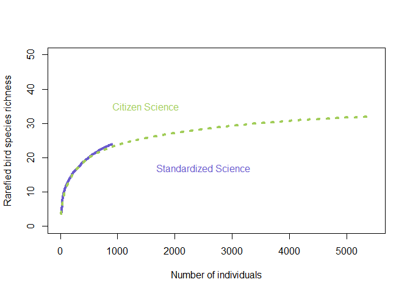

```r
#16-17:
ST16.17.nsample10<-seq(10,907,by=10)
CI16.17.nsample10<-seq(10,5451,by=10)
rich.ST16.17_10<-rarefy(ST16.17.SpComp,ST16.17.nsample10)
rich.CI16.17_10<-rarefy(CI16.17.SpComp,CI16.17.nsample10)

plot(ST16.17.nsample10, rich.ST16.17_10,type="l", xlab="Number of individuals", ylab="Rarefied bird species richness", lwd=4, col="slateblue", ylim=c(0,50), xlim=c(0,5460))
points(CI16.17.nsample10,rich.CI16.17_10,type="l", col="darkolivegreen3", lwd=4,lty=3)
text(2500,17,labels="Standardized Science", col="slateblue")
text(1500,35,labels="Citizen Science", col="darkolivegreen3")
```

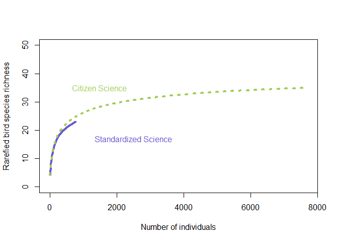

```r
#17-18:
ST17.18.nsample10<-seq(10,773,by=10)
CI17.18.nsample10<-seq(10,7692,by=10)
rich.ST17.18_10<-rarefy(ST17.18.SpComp,ST17.18.nsample10)
rich.CI17.18_10<-rarefy(CI17.18.SpComp,CI17.18.nsample10)

plot(ST17.18.nsample10, rich.ST17.18_10,type="l", xlab="Number of individuals", ylab="Rarefied bird species richness", lwd=4, col="slateblue", ylim=c(0,50), xlim=c(0,7700))
points(CI17.18.nsample10,rich.CI17.18_10,type="l", col="darkolivegreen3", lwd=4,lty=3)
text(2500,17,labels="Standardized Science", col="slateblue")
text(1500,35,labels="Citizen Science", col="darkolivegreen3")
```

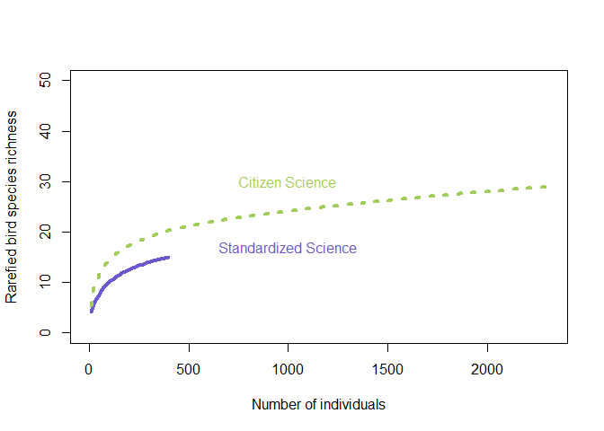

```r
#18-19:
ST18.19.nsample10<-seq(10,407,by=10)
CI18.19.nsample10<-seq(10,2306,by=10)
rich.ST18.19_10<-rarefy(ST18.19.SpComp,ST18.19.nsample10)
rich.CI18.19_10<-rarefy(CI18.19.SpComp,CI18.19.nsample10)

plot(ST18.19.nsample10, rich.ST18.19_10,type="l", xlab="Number of individuals", ylab="Rarefied bird species richness", lwd=4, col="slateblue", ylim=c(0,50), xlim=c(0,2310))
points(CI18.19.nsample10,rich.CI18.19_10,type="l", col="darkolivegreen3", lwd=4,lty=3)
text(1000,17,labels="Standardized Science", col="slateblue")
text(1000,30,labels="Citizen Science", col="darkolivegreen3")
```

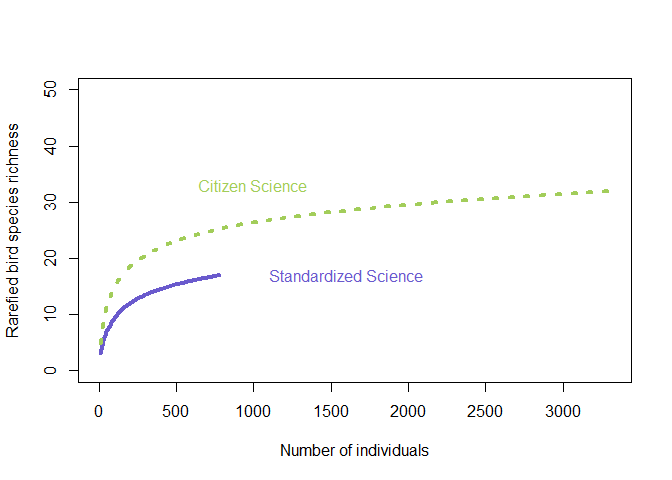

```r
#20-21:
ST20.21.nsample10<-seq(10,780,by=10)
CI20.21.nsample10<-seq(10,3307,by=10)
rich.ST20.21_10<-rarefy(ST20.21.SpComp,ST20.21.nsample10)
rich.CI20.21_10<-rarefy(CI20.21.SpComp,CI20.21.nsample10)

plot(ST20.21.nsample10, rich.ST20.21_10,type="l", xlab="Number of individuals", ylab="Rarefied bird species richness", lwd=4, col="slateblue", ylim=c(0,50), xlim=c(0,3310))
points(CI20.21.nsample10,rich.CI20.21_10,type="l", col="darkolivegreen3", lwd=4,lty=3)
text(1600,17,labels="Standardized Science", col="slateblue")
text(1000,33,labels="Citizen Science", col="darkolivegreen3")
```

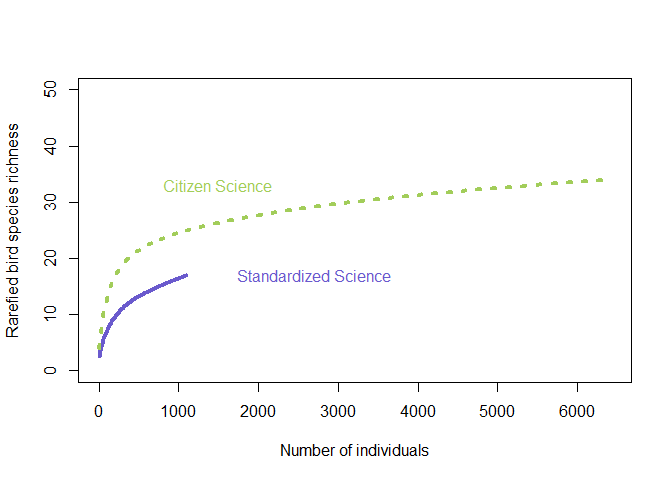

```r
#21-22:
ST21.22.nsample10<-seq(10,1097,by=10)
CI21.22.nsample10<-seq(10,6419,by=10)
rich.ST21.22_10<-rarefy(ST21.22.SpComp,ST21.22.nsample10)
rich.CI21.22_10<-rarefy(CI21.22.SpComp,CI21.22.nsample10)

plot(ST21.22.nsample10, rich.ST21.22_10,type="l", xlab="Number of individuals", ylab="Rarefied bird species richness", lwd=4, col="slateblue", ylim=c(0,50), xlim=c(0,6420))
points(CI21.22.nsample10,rich.CI21.22_10,type="l", col="darkolivegreen3", lwd=4,lty=3)
text(2700,17,labels="Standardized Science", col="slateblue")
text(1500,33,labels="Citizen Science", col="darkolivegreen3")
```

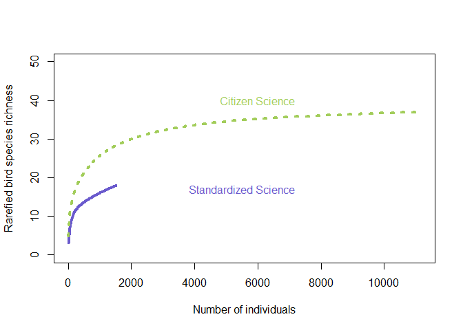

```r
#22-23:
ST22.23.nsample10<-seq(10,1521,by=10)
CI22.23.nsample10<-seq(10,11161,by=10)
rich.ST22.23_10<-rarefy(ST22.23.SpComp,ST22.23.nsample10)
rich.CI22.23_10<-rarefy(CI22.23.SpComp,CI22.23.nsample10)

plot(ST22.23.nsample10, rich.ST22.23_10,type="l", xlab="Number of individuals", ylab="Rarefied bird species richness", lwd=4, col="slateblue", ylim=c(0,50), xlim=c(0,11161))
points(CI22.23.nsample10,rich.CI22.23_10,type="l", col="darkolivegreen3", lwd=4,lty=3)
text(5500,17,labels="Standardized Science", col="slateblue")
text(6000,40,labels="Citizen Science", col="darkolivegreen3")
```

### Rarefaction by Sampling Method

for easier comparison and visual analysis, we created graphs that display all of the rarefaction curves from one sampling method together.

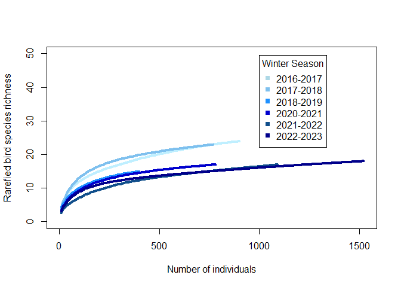

```r
# Standardized Science
plot(ST16.17.nsample10, rich.ST16.17_10,type="l", xlab="Number of individuals", ylab="Rarefied bird species richness", lwd=4, col="lightblue1", ylim=c(0,50), xlim=c(0,1525))
points(ST17.18.nsample10, rich.ST17.18_10,type="l", lwd=4, col="skyblue2")
points(ST18.19.nsample10, rich.ST18.19_10,type="l", lwd=4, col="dodgerblue")
points(ST20.21.nsample10, rich.ST20.21_10,type="l", lwd=4, col="mediumblue")
points(ST21.22.nsample10, rich.ST21.22_10,type="l", lwd=4, col="dodgerblue4")
points(ST22.23.nsample10, rich.ST22.23_10,type="l", lwd=4, col="darkblue")
#add a legend
legend(1000,49.5,legend=c("2016-2017","2017-2018","2018-2019","2020-2021","2021-2022","2022-2023"), pch=c(15,15,15,15,15,15), col=c("lightblue","skyblue2","dodgerblue","mediumblue","dodgerblue4","darkblue"),title="Winter Season")
```

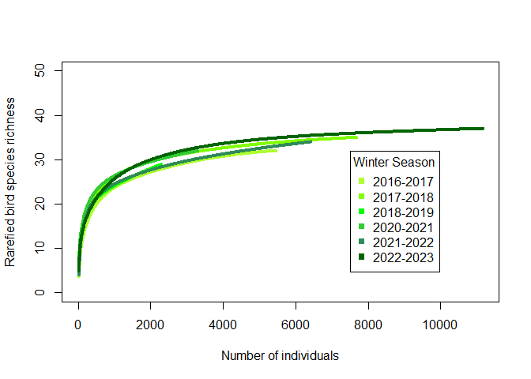

```r
#Citizen Science
plot(CI16.17.nsample10, rich.CI16.17_10,type="l", xlab="Number of individuals", ylab="Rarefied bird species richness", lwd=4, col="greenyellow", ylim=c(0,50), xlim=c(0,11161))
points(CI17.18.nsample10,rich.CI17.18_10,type="l", col="chartreuse", lwd=4)
points(CI18.19.nsample10,rich.CI18.19_10,type="l", col="green", lwd=4)
points(CI20.21.nsample10,rich.CI20.21_10,type="l", col="limegreen", lwd=4)
points(CI21.22.nsample10,rich.CI21.22_10,type="l", col="seagreen4", lwd=4)
points(CI22.23.nsample10,rich.CI22.23_10,type="l", col="darkgreen", lwd=4)
legend(7500,32,legend=c("2016-2017","2017-2018","2018-2019","2020-2021","2021-2022","2022-2023"), pch=c(15,15,15,15,15,15), col=c("greenyellow","chartreuse","green","limegreen","seagreen4","darkgreen"),title="Winter Season")
```

### All Rarefaction Curves

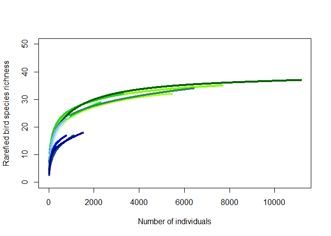

```r
plot(CI16.17.nsample10, rich.CI16.17_10,type="l", xlab="Number of individuals", ylab="Rarefied bird species richness", lwd=4, col="greenyellow", ylim=c(0,50), xlim=c(0,11161))
points(CI17.18.nsample10,rich.CI17.18_10,type="l", col="chartreuse", lwd=4)
points(CI18.19.nsample10,rich.CI18.19_10,type="l", col="green", lwd=4)
points(CI20.21.nsample10,rich.CI20.21_10,type="l", col="limegreen", lwd=4)
points(CI21.22.nsample10,rich.CI21.22_10,type="l", col="seagreen4", lwd=4)
points(CI22.23.nsample10,rich.CI22.23_10,type="l", col="darkgreen", lwd=4)
points(ST16.17.nsample10, rich.ST16.17_10,type="l",lwd=4, col="lightblue1")
points(ST17.18.nsample10, rich.ST17.18_10,type="l", lwd=4, col="skyblue2")
points(ST18.19.nsample10, rich.ST18.19_10,type="l", lwd=4, col="dodgerblue")
points(ST20.21.nsample10, rich.ST20.21_10,type="l", lwd=4, col="mediumblue")
points(ST21.22.nsample10, rich.ST21.22_10,type="l", lwd=4, col="dodgerblue4")
points(ST22.23.nsample10, rich.ST22.23_10,type="l", lwd=4, col="darkblue")
```

# Asymptotic Richness Estimator (Chao1)

Chao1 was used to estimate total species richness by using a preset equation of the singletons and doubletons of species abundance found in the data. The Output table was limited after the first data set to only include the output we are looking for.

```r
#estimated richness = sample richness plus (singletons-(singletons-1))/(2 times(doubletons plus 1))
#Use ChaoSpecies() function in  the SpadeR package, using abundance data.

#Whole output:
#CHAO1 ESTIMATOR NUMBERS K=10, CONF=0.95
ChaoSpecies(ST16.17.SpComp, datatype="abundance", k=10, conf=0.95)
```

[output not shown]

```r
#limited output to desired information only:

#CHAO1 ESTIMATOR NUMBERS K=10, CONF=0.95
ChaoSpecies(ST16.17.SpComp, datatype="abundance", k=10, conf=0.95)$Species_table[3,]
```

```
## Estimate     s.e. 95%Lower 95%Upper
##   27.596    3.848   24.649   43.923
```

```r
ChaoSpecies(CI16.17.SpComp, datatype="abundance", k=10, conf=0.95)$Species_table[3,]
```

```
## Estimate     s.e. 95%Lower 95%Upper
##   32.750    1.262   32.077   39.273
```

```r
ChaoSpecies(ST17.18.SpComp, datatype="abundance", k=10, conf=0.95)$Species_table[3,]
```

```
## Estimate     s.e. 95%Lower 95%Upper
##   29.242    7.543   23.972   63.082
```

```r
ChaoSpecies(CI17.18.SpComp, datatype="abundance", k=10, conf=0.95)$Species_table[3,]
```

```
## Estimate     s.e. 95%Lower 95%Upper
##   36.500    2.291   35.175   47.883
```

```r
ChaoSpecies(ST18.19.SpComp, datatype="abundance", k=10, conf=0.95)$Species_table[3,]
```

```
## Estimate     s.e. 95%Lower 95%Upper
##   16.496    2.286   15.174   27.859
```

```r
ChaoSpecies(CI18.19.SpComp, datatype="abundance", k=10, conf=0.95)$Species_table[3,]
```

```
## Estimate     s.e. 95%Lower 95%Upper
##   41.245   13.149   31.201   97.135
```

```r
ChaoSpecies(ST20.21.SpComp, datatype="abundance", k=10, conf=0.95)$Species_table[3,]
```

```
## Estimate     s.e. 95%Lower 95%Upper
##   24.990   11.647   17.986   81.738
```

```r
ChaoSpecies(CI20.21.SpComp, datatype="abundance", k=10, conf=0.95)$Species_table[3,]
```

```
## Estimate     s.e. 95%Lower 95%Upper
##   36.165    4.882   32.673   57.764
```

```r
ChaoSpecies(ST21.22.SpComp, datatype="abundance", k=10, conf=0.95)$Species_table[3,]
```

```
## Estimate     s.e. 95%Lower 95%Upper
##   34.984   23.601   19.530  144.850
```

```r
ChaoSpecies(CI21.22.SpComp, datatype="abundance", k=10, conf=0.95)$Species_table[3,]
```

```
## Estimate     s.e. 95%Lower 95%Upper
##   39.999    6.480   35.071   67.617
```

```r
ChaoSpecies(ST22.23.SpComp, datatype="abundance", k=10, conf=0.95)$Species_table[3,]
```

```
## Estimate     s.e. 95%Lower 95%Upper
##   24.246    7.547   18.973   58.106
```

```r
ChaoSpecies(CI22.23.SpComp, datatype="abundance", k=10, conf=0.95)$Species_table[3,]
```

```
## Estimate     s.e. 95%Lower 95%Upper
##   40.000    4.609   37.347   62.954
```

# Sampling Completeness Estimator

To estimate sampling completeness, the raw richness was divided by the Chao1 richness estimate. This was completed for the estimated number itself, as well as the upper and lower confidence interval.

```r
#ST16-17:
24/27.596
```

```
## [1] 0.8696913
```

```r
#CI16-17:
32/32.750
```

```
## [1] 0.9770992
```

```r
#ST17-18:
23/29.242
```

```
## [1] 0.7865399
```

```r
#CI17-18:
35/36.5
```

```
## [1] 0.9589041
```

```r
#ST18-19:
15/16.496
```

```
## [1] 0.9093113
```

```r
#CI18-19:
29/41.245
```

```
## [1] 0.7031155
```

```r
#ST20-21:
17/24.990
```

```
## [1] 0.6802721
```

```r
#CI20-21:
32/36.165
```

```
## [1] 0.8848334
```

```r
#ST21-22:
17/34.984
```

```
## [1] 0.4859364
```

```r
#CI21-22:
34/39.999
```

```
## [1] 0.8500213
```

```r
#ST22-23:
18/24.246
```

```
## [1] 0.7423905
```

```r
#SST22-23:
37/40
```

```
## [1] 0.925
```

```r
#recorded results in book.
#can also get percents of upper and lower estimate

#Chao1 richness/lower:
#ST16-17:
24/24.649
```

```
## [1] 0.9736703
```

```r
#CI16-17:
32/32.077
```

```
## [1] 0.9975995
```

```r
#ST17-18:
23/23.972
```

```
## [1] 0.9594527
```

```r
#CI17-18:
35/35.175
```

```
## [1] 0.9950249
```

```r
#ST18-19:
15/15.174
```

```
## [1] 0.988533
```

```r
#CI18-19:
29/31.201
```

```
## [1] 0.9294574
```

```r
#ST20-21:
17/17.986
```

```
## [1] 0.9451796
```

```r
#CI20-21:
32/32.673
```

```
## [1] 0.979402
```

```r
#ST21-22:
17/19.530
```

```
## [1] 0.8704557
```

```r
#CI21-22:
34/35.071
```

```
## [1] 0.9694619
```

```r
#ST22-23:
18/18.973
```

```
## [1] 0.9487166
```

```r
#SST22-23:
37/37.347
```

```
## [1] 0.9907088
```

```r
#Chao1 richness/upper:

#ST16-17:
24/43.923
```

```
## [1] 0.5464108
```

```r
#CI16-17:
32/39.273
```

```
## [1] 0.8148092
```

```r
#ST17-18:
23/63.082
```

```
## [1] 0.3646048
```

```r
#CI17-18:
35/47.883
```

```
## [1] 0.7309484
```

```r
#ST18-19:
15/27.859
```

```
## [1] 0.5384256
```

```r
#CI18-19:
29/97.135
```

```
## [1] 0.2985536
```

```r
#ST20-21:
17/81.738
```

```
## [1] 0.2079816
```

```r
#CI20-21:
32/57.764
```

```
## [1] 0.5539783
```

```r
#ST21-22:
17/144.850
```

```
## [1] 0.1173628
```

```r
#CI21-22:
34/67.617
```

```
## [1] 0.5028321
```

```r
#ST22-23:
18/58.106
```

```
## [1] 0.3097787
```

```r
#SST22-23:
37/62.954
```

```
## [1] 0.5877307
```

# T-tests

All variables being tested passed the Shapiro-Wilk test of normality and the Fligner-Killeen test of homogeneity, meaning the assumptions for the two-sampled t-test are met. Then the t-test was performed.

### Raw Species Richness

```r
Table1.dat<-read.csv("TTests Table 1.csv")

#Test homogeneity (Fligner-Killeen)

fligner.test(Table1.dat$Raw.Species.Richness~Table1.dat$Collection.Method)
```

```
##
##  Fligner-Killeen test of homogeneity of variances
##
## data:  Table1.dat$Raw.Species.Richness by Table1.dat$Collection.Method
## Fligner-Killeen:med chi-squared = 0.011917, df = 1, p-value = 0.9131
```

```r
#output was not statistically significant. Can assume homogeneity of variances (homoscedasticity)

#Test normality (Shapiro-Wilk)

#separate the samples to compare individually
T.Standard<-Table1.dat %>% filter(Collection.Method=="Standardized")

T.Citizen<-Table1.dat %>% filter(Collection.Method== "Citizen")

#run Shapiro test

shapiro.test(T.Standard$Raw.Species.Richness)
```

```
##
##  Shapiro-Wilk normality test
##
## data:  T.Standard$Raw.Species.Richness
## W = 0.8658, p-value = 0.21
```

```r
shapiro.test(T.Citizen$Raw.Species.Richness)
```

```
##
##  Shapiro-Wilk normality test
##
## data:  T.Citizen$Raw.Species.Richness
## W = 0.97791, p-value = 0.9407
```

```r
#both outputs not statistically significant. Can assume normality.

#all assumptions for normal two-sampled t-test is met. Perform t-test

t.test(Table1.dat$Raw.Species.Richness~Table1.dat$Collection.Method, alternative = "two.sided", var.equal = TRUE)
```

```
##
##  Two Sample t-test
##
## data:  Table1.dat$Raw.Species.Richness by Table1.dat$Collection.Method
## t = 7.5784, df = 10, p-value = 1.886e-05
## alternative hypothesis: true difference in means between group Citizen and group Standardized is not equal to 0
## 95 percent confidence interval:
##  10.00151 18.33182
## sample estimates:
##      mean in group Citizen mean in group Standardized
##                   33.16667                   19.00000
```

### Rarefied Species Richness

```r
#Test homogeneity (Fligner-Killeen)

fligner.test(Table1.dat$Rarefied.Richness~Table1.dat$Collection.Method)
```

```
##
##  Fligner-Killeen test of homogeneity of variances
##
## data:  Table1.dat$Rarefied.Richness by Table1.dat$Collection.Method
## Fligner-Killeen:med chi-squared = 1.3036, df = 1, p-value = 0.2536
```

```r
#output was not statistically significant. Can assume homogeneity of variances (homoscedasticity)

#Test normality (Shapiro-Wilk)

shapiro.test(T.Standard$Rarefied.Richness)
```

```
##
##  Shapiro-Wilk normality test
##
## data:  T.Standard$Rarefied.Richness
## W = 0.8658, p-value = 0.21
```

```r
shapiro.test(T.Citizen$Rarefied.Richness)
```

```
##
##  Shapiro-Wilk normality test
##
## data:  T.Citizen$Rarefied.Richness
## W = 0.94851, p-value = 0.7282
```

```r
#both outputs not statistically significant. Can assume normality.

#all assumptions for normal two-sampled t-test is met. Perform t-test

t.test(Table1.dat$Rarefied.Richness~Table1.dat$Collection.Method, alternative = "two.sided", var.equal = TRUE)
```

```
##
##  Two Sample t-test
##
## data:  Table1.dat$Rarefied.Richness by Table1.dat$Collection.Method
## t = 3.0016, df = 10, p-value = 0.01331
## alternative hypothesis: true difference in means between group Citizen and group Standardized is not equal to 0
## 95 percent confidence interval:
##  1.415885 9.573988
## sample estimates:
##      mean in group Citizen mean in group Standardized
##                   24.49494                   19.00000
```

### Shannon’s Diversity Index

```r
#Test homogeneity (Fligner-Killeen)

fligner.test(Table1.dat$Shannon.s.Diversity.Index~Table1.dat$Collection.Method)
```

```
##
##  Fligner-Killeen test of homogeneity of variances
##
## data:  Table1.dat$Shannon.s.Diversity.Index by Table1.dat$Collection.Method
## Fligner-Killeen:med chi-squared = 0.35565, df = 1, p-value = 0.5509
```

```r
#output was not statistically significant. Can assume homogeneity of variances (homoscedasticity)

#Test normality (Shapiro-Wilk)

shapiro.test(T.Standard$Shannon.s.Diversity.Index)
```

```
##
##  Shapiro-Wilk normality test
##
## data:  T.Standard$Shannon.s.Diversity.Index
## W = 0.84262, p-value = 0.137
```

```r
shapiro.test(T.Citizen$Shannon.s.Diversity.Index)
```

```
##
##  Shapiro-Wilk normality test
##
## data:  T.Citizen$Shannon.s.Diversity.Index
## W = 0.91938, p-value = 0.5009
```

```r
#both outputs not statistically significant. Can assume normality.

#all assumptions for normal two-sampled t-test is met. Perform t-test

t.test(Table1.dat$Shannon.s.Diversity.Index~Table1.dat$Collection.Method, alternative = "two.sided", var.equal = TRUE)
```

```
##
##  Two Sample t-test
##
## data:  Table1.dat$Shannon.s.Diversity.Index by Table1.dat$Collection.Method
## t = 2.6703, df = 10, p-value = 0.02348
## alternative hypothesis: true difference in means between group Citizen and group Standardized is not equal to 0
## 95 percent confidence interval:
##  0.3623929 4.0149948
## sample estimates:
##      mean in group Citizen mean in group Standardized
##                   6.177006                   3.988312
```

### Simpson’s Diversity Index

```r
#Test homogeneity (Fligner-Killeen)

fligner.test(Table1.dat$Simpson.s.Diversity.Index~Table1.dat$Collection.Method)
```

```
##
##  Fligner-Killeen test of homogeneity of variances
##
## data:  Table1.dat$Simpson.s.Diversity.Index by Table1.dat$Collection.Method
## Fligner-Killeen:med chi-squared = 0.19202, df = 1, p-value = 0.6612
```

```r
#output was not statistically significant. Can assume homogeneity of variances (homoscedasticity)

#Test normality (Shapiro-Wilk)

shapiro.test(T.Standard$Simpson.s.Diversity.Index)
```

```
##
##  Shapiro-Wilk normality test
##
## data:  T.Standard$Simpson.s.Diversity.Index
## W = 0.89449, p-value = 0.3424
```

```r
shapiro.test(T.Citizen$Simpson.s.Diversity.Index)
```

```
##
##  Shapiro-Wilk normality test
##
## data:  T.Citizen$Simpson.s.Diversity.Index
## W = 0.83387, p-value = 0.1159
```

```r
#both outputs not statistically significant. Can assume normality.

#all assumptions for normal two-sampled t-test is met. Perform t-test

t.test(Table1.dat$Simpson.s.Diversity.Index~Table1.dat$Collection.Method, alternative = "two.sided", var.equal = TRUE)
```

```
##
##  Two Sample t-test
##
## data:  Table1.dat$Simpson.s.Diversity.Index by Table1.dat$Collection.Method
## t = 1.8203, df = 10, p-value = 0.09872
## alternative hypothesis: true difference in means between group Citizen and group Standardized is not equal to 0
## 95 percent confidence interval:
##  -0.2288788  2.2722044
## sample estimates:
##      mean in group Citizen mean in group Standardized
##                   3.630447                   2.608784
```

### Chao1 Richness Estimate

```r
Table2.dat<-read.csv("TTests Table 2.csv")

#Test homogeneity (Fligner-Killeen)

fligner.test(Table2.dat$Chao1.Richness.Estimate~Table2.dat$Collection.Method)
```

```
##
##  Fligner-Killeen test of homogeneity of variances
##
## data:  Table2.dat$Chao1.Richness.Estimate by Table2.dat$Collection.Method
## Fligner-Killeen:med chi-squared = 0.2123, df = 1, p-value = 0.645
```

```r
#output was not statistically significant. Can assume homogeneity of variances (homoscedasticity)

#Test normality (Shapiro-Wilk)

#separate the samples to compare individually
T.Standard2<-Table2.dat %>% filter(Collection.Method=="Standardized")

T.Citizen2<-Table2.dat %>% filter(Collection.Method== "Citizen")

#run Shapiro test

shapiro.test(T.Standard2$Chao1.Richness.Estimate)
```

```
##
##  Shapiro-Wilk normality test
##
## data:  T.Standard2$Chao1.Richness.Estimate
## W = 0.97333, p-value = 0.914
```

```r
shapiro.test(T.Citizen2$Chao1.Richness.Estimate)
```

```
##
##  Shapiro-Wilk normality test
##
## data:  T.Citizen2$Chao1.Richness.Estimate
## W = 0.91208, p-value = 0.4502
```

```r
#both outputs not statistically significant. Can assume normality.

#all assumptions for normal two-sampled t-test is met. Perform t-test

t.test(Table2.dat$Chao1.Richness.Estimate~Table2.dat$Collection.Method, alternative = "two.sided", var.equal = TRUE)
```

```
##
##  Two Sample t-test
##
## data:  Table2.dat$Chao1.Richness.Estimate by Table2.dat$Collection.Method
## t = 4.0789, df = 10, p-value = 0.002218
## alternative hypothesis: true difference in means between group Citizen and group Standardized is not equal to 0
## 95 percent confidence interval:
##   5.225934 17.809066
## sample estimates:
##      mean in group Citizen mean in group Standardized
##                    37.7765                    26.2590
```

# Special Thanks

We would like to give a special thanks to Dr. Carol Frost and Mr. Kyle Taylor for their assistance in problem solving issues and advice with R.